# Industry 4.0 의 중심, AI - ML&DL

Machine Learning & Deep Learning with TensorFlow @ [FB / jskim.kr](https://www.facebook.com/jskim.kr), 김진수

# Sect7. Learning rate, Evaluation

```python
from images import bigpycraft_ai as bpc
from IPython.display import Image
from tqdm import tqdm_notebook
```

### Training and Test datasets

[figure not shown]

```python
bpc.Figure(bpc.ML07_IMG_01)
```

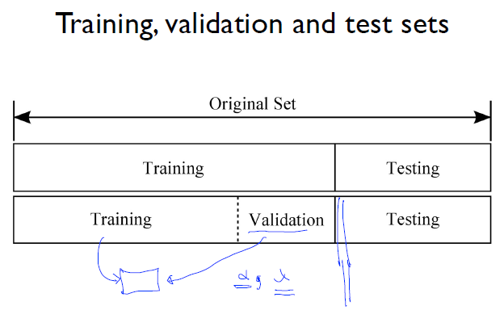

```python
bpc.Figure(bpc.ML07_IMG_02)
```

### learning_rate 에 따른 학습

> - Case1 : learning_rate = 0.1
> - Case2 : learning_rate = 1.5
> - Case3 : learning_rate = 1e-5

### Case1 : learning_rate = 0.1

```python
import tensorflow as tf
import numpy as np
tf.set_random_seed(777)  # for reproducibility

learning_rate = 0.1

x_data = [[1, 2, 1], [1, 3, 2], [1, 3, 4], [1, 5, 5], [1, 7, 5], [1, 2, 5], [1, 6, 6], [1, 7, 7]]
y_data = [[0, 0, 1], [0, 0, 1], [0, 0, 1], [0, 1, 0], [0, 1, 0], [0, 1, 0], [1, 0, 0], [1, 0, 0]]

# Evaluation our model using this test dataset
x_test = [[2, 1, 1], [3, 1, 2], [3, 3, 4]]
y_test = [[0, 0, 1], [0, 0, 1], [0, 0, 1]]

X = tf.placeholder("float", [None, 3])
Y = tf.placeholder("float", [None, 3])

W = tf.Variable(tf.random_normal([3, 3]))
b = tf.Variable(tf.random_normal([3]))

# tf.nn.softmax computes softmax activations
# softmax = exp(logits) / reduce_sum(exp(logits), dim)
hypothesis = tf.nn.softmax(tf.matmul(X, W) + b)

# Cross entropy cost/loss
cost = tf.reduce_mean(-tf.reduce_sum(Y * tf.log(hypothesis), axis=1))

# Try to change learning_rate to small numbers
optimizer = tf.train.GradientDescentOptimizer(
    learning_rate=learning_rate).minimize(cost)

# Correct prediction Test model
prediction = tf.arg_max(hypothesis, 1)
is_correct = tf.equal(prediction, tf.arg_max(Y, 1))
accuracy   = tf.reduce_mean(tf.cast(is_correct, tf.float32))
```

```
WARNING:tensorflow:From <ipython-input-4-f7a8fccb1f68>:32: arg_max (from tensorflow.python.ops.gen_math_ops) is deprecated and will be removed in a future version.
Instructions for updating:
Use `argmax` instead
```

```python
# Launch graph
with tf.Session() as sess:
    # Initialize TensorFlow variables
    sess.run(tf.global_variables_initializer())

    for step in tqdm_notebook(range(201)):
        cost_val, W_val, _ = sess.run(
            [cost, W, optimizer], feed_dict={X: x_data, Y: y_data})
        if step%20 == 0:
            print("\n Step : {} \n Cost : {} \n Weight : \n{}".format(step, cost_val, W_val))

    print("-"*60)
    # predict
    print("Prediction \t:", sess.run(prediction, feed_dict={X: x_test}))
    # Calculate the accuracy
    print("Accuracy \t: ", sess.run(accuracy, feed_dict={X: x_test, Y: y_test}))
```

```
 Step : 0
 Cost : 5.732029914855957
 Weight :
[[ 0.7288166   0.7153621  -1.1801533 ]
 [-0.57753736 -0.12988332  1.6072978 ]
 [ 0.48373488 -0.51433605 -2.02127   ]]

 Step : 20
 Cost : 1.6610023975372314
 Weight :
[[ 0.35837555  0.7006911  -0.79504126]
 [-0.5218104  -0.14752226  1.5692096 ]
 [-0.00524238 -0.21694626 -1.8296826 ]]

 Step : 40
 Cost : 1.4070582389831543
 Weight :
[[ 0.08632906  0.6441534  -0.4664571 ]
 [-0.27831453 -0.19541714  1.3736086 ]
 [-0.14105876 -0.16434807 -1.7464645 ]]

 Step : 60
 Cost : 1.2188071012496948
 Weight :
[[-0.14574495  0.580433   -0.17066269]
 [-0.1107576  -0.17286882  1.1835034 ]
 [-0.2245029  -0.17601469 -1.6513535 ]]

 Step : 80
 Cost : 1.071008563041687
 Weight :
[[-0.3455095   0.5168773   0.09265763]
 [ 0.01382132 -0.11677328  1.0028291 ]
 [-0.28096494 -0.21812555 -1.5527805 ]]

 Step : 100
 Cost : 0.9537603259086609
 Weight :
[[-0.52009284  0.45806164  0.32605675]
 [ 0.11236367 -0.04872466  0.836238  ]
```

[output cut: 25 more lines]

```
 Weight :
[[-1.0534288   0.30107263  1.016382  ]
 [ 0.34702814  0.16383716  0.38901168]
 [-0.3671113  -0.4252324  -1.2595268 ]]

 Step : 200
 Cost : 0.6709087491035461
 Weight :
[[-1.1588541   0.28058422  1.1422957 ]
 [ 0.37609792  0.19073224  0.33304682]
 [-0.35536593 -0.44033223 -1.2561723 ]]

------------------------------------------------------------
Prediction 	: [2 2 2]
Accuracy 	:  1.0
```

### Case2 : learning_rate = 1.5

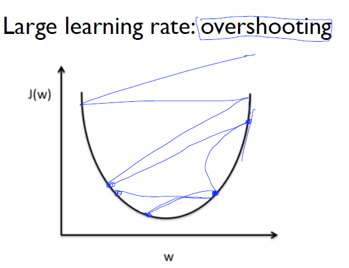

```python
bpc.Figure(bpc.ML07_IMG_03)
```

```python
import tensorflow as tf
import numpy as np

tf.set_random_seed(777)  # for reproducibility

learning_rate = 1.5

x_data = [[1, 2, 1], [1, 3, 2], [1, 3, 4], [1, 5, 5], [1, 7, 5], [1, 2, 5], [1, 6, 6], [1, 7, 7]]
y_data = [[0, 0, 1], [0, 0, 1], [0, 0, 1], [0, 1, 0], [0, 1, 0], [0, 1, 0], [1, 0, 0], [1, 0, 0]]

# Evaluation our model using this test dataset
x_test = [[2, 1, 1], [3, 1, 2], [3, 3, 4]]
y_test = [[0, 0, 1], [0, 0, 1], [0, 0, 1]]

X = tf.placeholder("float", [None, 3])
Y = tf.placeholder("float", [None, 3])

W = tf.Variable(tf.random_normal([3, 3]))
b = tf.Variable(tf.random_normal([3]))

# tf.nn.softmax computes softmax activations
# softmax = exp(logits) / reduce_sum(exp(logits), dim)
hypothesis = tf.nn.softmax(tf.matmul(X, W) + b)

# Cross entropy cost/loss
cost = tf.reduce_mean(-tf.reduce_sum(Y * tf.log(hypothesis), axis=1))

# Try to change learning_rate to small numbers
optimizer = tf.train.GradientDescentOptimizer(
    learning_rate=learning_rate).minimize(cost)

# Correct prediction Test model
prediction = tf.arg_max(hypothesis, 1)
is_correct = tf.equal(prediction, tf.arg_max(Y, 1))
accuracy = tf.reduce_mean(tf.cast(is_correct, tf.float32))
```

```python
# Launch graph
with tf.Session() as sess:
    # Initialize TensorFlow variables
    sess.run(tf.global_variables_initializer())

    for step in range(201):
        cost_val, W_val, _ = sess.run(
            [cost, W, optimizer], feed_dict={X: x_data, Y: y_data})
        if step%20 == 0 or step<5:
            print("\n Step : {} \n Cost : {} \n Weight : \n{}".format(step, cost_val, W_val))
    print("-"*60)
    # predict
    print("Prediction \t:", sess.run(prediction, feed_dict={X: x_test}))
    # Calculate the accuracy
    print("Accuracy \t: ", sess.run(accuracy, feed_dict={X: x_test, Y: y_test}))
```

```
 Step : 0
 Cost : 5.191886901855469
 Weight :
[[-1.7491041   0.25865757  2.020178  ]
 [ 1.7919745  -4.259283    1.9250852 ]
 [ 2.9499474  -2.2450333  -1.0560418 ]]

 Step : 1
 Cost : 23.448177337646484
 Weight :
[[-2.8552833   0.8211576   2.563857  ]
 [-2.29496    -1.6342831   3.3870196 ]
 [-1.155808    0.56746674  0.23721349]]

 Step : 2
 Cost : 21.729793548583984
 Weight :
[[-2.4802833   1.3836521   1.6263626 ]
 [ 0.14253998  0.99070597 -1.6754694 ]
 [ 1.281692    3.379944   -5.0127635 ]]

 Step : 3
 Cost : 15.789323806762695
 Weight :
[[-2.1055264   0.44639546  2.1888623 ]
 [ 2.5795412  -2.9462953  -0.17546964]
 [ 3.718936   -0.36979985 -3.7002635 ]]

 Step : 4
 Cost : 25.514022827148438
 Weight :
[[-3.2305205   1.0088954   2.7513564 ]
 [-1.5454464  -0.32129526  1.3245184 ]
 [-0.40605783  2.4427001  -2.3877695 ]]

 Step : 20
 Cost : nan
 Weight :
[[nan nan nan]
 [nan nan nan]
```

[output cut: 52 more lines]

```
 Cost : nan
 Weight :
[[nan nan nan]
 [nan nan nan]
 [nan nan nan]]

 Step : 200
 Cost : nan
 Weight :
[[nan nan nan]
 [nan nan nan]
 [nan nan nan]]
------------------------------------------------------------
Prediction 	: [0 0 0]
Accuracy 	:  0.0
```

### Case3 : learning_rate = 1e-5

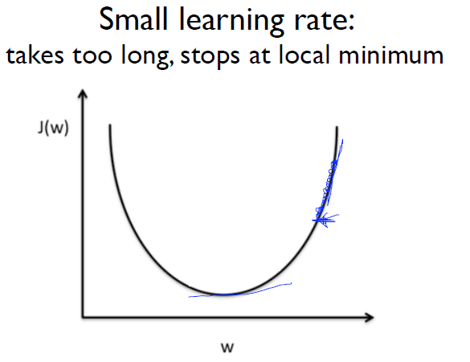

```python
bpc.Figure(bpc.ML07_IMG_04)
```

```python
import tensorflow as tf
import numpy as np

tf.set_random_seed(777)  # for reproducibility

learning_rate = 1e-5

x_data = [[1, 2, 1], [1, 3, 2], [1, 3, 4], [1, 5, 5], [1, 7, 5], [1, 2, 5], [1, 6, 6], [1, 7, 7]]
y_data = [[0, 0, 1], [0, 0, 1], [0, 0, 1], [0, 1, 0], [0, 1, 0], [0, 1, 0], [1, 0, 0], [1, 0, 0]]

# Evaluation our model using this test dataset
x_test = [[2, 1, 1], [3, 1, 2], [3, 3, 4]]
y_test = [[0, 0, 1], [0, 0, 1], [0, 0, 1]]

X = tf.placeholder("float", [None, 3])
Y = tf.placeholder("float", [None, 3])

W = tf.Variable(tf.random_normal([3, 3]))
b = tf.Variable(tf.random_normal([3]))

# tf.nn.softmax computes softmax activations
# softmax = exp(logits) / reduce_sum(exp(logits), dim)
hypothesis = tf.nn.softmax(tf.matmul(X, W) + b)

# Cross entropy cost/loss
cost = tf.reduce_mean(-tf.reduce_sum(Y * tf.log(hypothesis), axis=1))

# Try to change learning_rate to small numbers
optimizer = tf.train.GradientDescentOptimizer(
    learning_rate=learning_rate).minimize(cost)

# Correct prediction Test model
prediction = tf.arg_max(hypothesis, 1)
is_correct = tf.equal(prediction, tf.arg_max(Y, 1))
accuracy = tf.reduce_mean(tf.cast(is_correct, tf.float32))
```

```python
# Launch graph
with tf.Session() as sess:
    # Initialize TensorFlow variables
    sess.run(tf.global_variables_initializer())

    for step in range(201):
        cost_val, W_val, _ = sess.run(
            [cost, W, optimizer], feed_dict={X: x_data, Y: y_data})
        if step%20 == 0:
            print("\n Step : {} \n Cost : {} \n Weight : \n{}".format(step, cost_val, W_val))

    print("-"*60)
    # predict
    print("Prediction \t:", sess.run(prediction, feed_dict={X: x_test}))
    # Calculate the accuracy
    print("Accuracy \t: ", sess.run(accuracy, feed_dict={X: x_test, Y: y_test}))
```

```
 Step : 0
 Cost : 6.202129364013672
 Weight :
[[-0.82213634 -0.2921946   0.99954295]
 [ 1.2207106  -0.5764077  -1.4112477 ]
 [-0.65411896 -0.61369926 -1.5307263 ]]

 Step : 20
 Cost : 6.197155952453613
 Weight :
[[-0.82228535 -0.2921207   0.99961805]
 [ 1.2201623  -0.5760596  -1.4110475 ]
 [-0.65466493 -0.6133273  -1.5305523 ]]

 Step : 40
 Cost : 6.192182540893555
 Weight :
[[-0.82243437 -0.2920468   0.99969316]
 [ 1.2196139  -0.5757115  -1.4108472 ]
 [-0.6552109  -0.6129554  -1.5303782 ]]

 Step : 60
 Cost : 6.1872100830078125
 Weight :
[[-0.8225834  -0.29197288  0.99976826]
 [ 1.2190655  -0.5753634  -1.4106469 ]
 [-0.6557569  -0.61258346 -1.5302042 ]]

 Step : 80
 Cost : 6.182237148284912
 Weight :
[[-0.8227324  -0.29189897  0.99984336]
 [ 1.2185172  -0.5750153  -1.4104466 ]
 [-0.65630287 -0.6122115  -1.5300301 ]]

 Step : 100
 Cost : 6.177264213562012
 Weight :
[[-0.8228814  -0.29182506  0.99991846]
 [ 1.2179688  -0.5746672  -1.4102464 ]
```

[output cut: 24 more lines]

```
 Cost : 6.157376289367676
 Weight :
[[-0.82347745 -0.29152942  1.0002154 ]
 [ 1.2157754  -0.57327485 -1.4094453 ]
 [-0.65903276 -0.61035186 -1.5291599 ]]

 Step : 200
 Cost : 6.152405738830566
 Weight :
[[-0.82362646 -0.2914555   1.0002893 ]
 [ 1.215227   -0.57292676 -1.409245  ]
 [-0.65957874 -0.6099799  -1.5289859 ]]
------------------------------------------------------------
Prediction 	: [0 2 0]
Accuracy 	:  0.33333334
```

### Non-normalized inputs

> Linear regression without min, max
> - 너무나 심플하고 멋진 모델임에도 불구하고 학습해보면 NaN 이 발생
> - 해결방안 : Nomalized 한다거나, MinMaxScaler 함수 사용

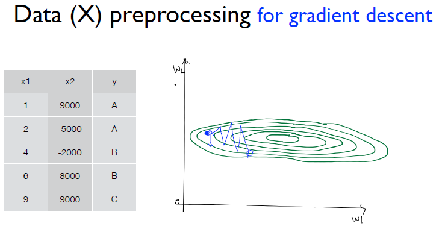

```python
bpc.Figure(bpc.ML07_IMG_05)
```

```python
import tensorflow as tf
import numpy as np

tf.set_random_seed(777)  # for reproducibility

xy = np.array([[828.659973, 833.450012, 908100,  828.349976, 831.659973],
               [823.02002,  828.070007, 1828100, 821.655029, 828.070007],
               [819.929993, 824.400024, 1438100, 818.97998,  824.159973],
               [816,        820.958984, 1008100, 815.48999,  819.23999 ],
               [819.359985, 823,        1188100, 818.469971, 818.97998 ],
               [819,        823,        1198100, 816,        820.450012],
               [811.700012, 815.25,     1098100, 809.780029, 813.669983],
               [809.51001,  816.659973, 1398100, 804.539978, 809.559998]])
# print(xy)

x_data = xy[:, 0:-1]
y_data = xy[:, [-1]]
print(" x_data : \n{}  \n\n y_data : \n{}".format(x_data, y_data))

# placeholders for a tensor that will be always fed.
X = tf.placeholder(tf.float32, shape=[None, 4])
Y = tf.placeholder(tf.float32, shape=[None, 1])

W = tf.Variable(tf.random_normal([4, 1]), name='weight')
b = tf.Variable(tf.random_normal([1]), name='bias')

# Hypothesis
hypothesis = tf.matmul(X, W) + b

# Simplified cost/loss function
cost = tf.reduce_mean(tf.square(hypothesis - Y))

# Minimize
optimizer = tf.train.GradientDescentOptimizer(learning_rate=1e-5)
train = optimizer.minimize(cost)
```

```
 x_data :
[[8.28659973e+02 8.33450012e+02 9.08100000e+05 8.28349976e+02]
 [8.23020020e+02 8.28070007e+02 1.82810000e+06 8.21655029e+02]
 [8.19929993e+02 8.24400024e+02 1.43810000e+06 8.18979980e+02]
 [8.16000000e+02 8.20958984e+02 1.00810000e+06 8.15489990e+02]
 [8.19359985e+02 8.23000000e+02 1.18810000e+06 8.18469971e+02]
 [8.19000000e+02 8.23000000e+02 1.19810000e+06 8.16000000e+02]
 [8.11700012e+02 8.15250000e+02 1.09810000e+06 8.09780029e+02]
 [8.09510010e+02 8.16659973e+02 1.39810000e+06 8.04539978e+02]]

 y_data :
[[831.659973]
 [828.070007]
 [824.159973]
 [819.23999 ]
 [818.97998 ]
 [820.450012]
 [813.669983]
 [809.559998]]
```

```python
# Launch the graph in a session.
sess = tf.Session()
# Initializes global variables in the graph.
sess.run(tf.global_variables_initializer())

for step in range(101):
    cost_val, hy_val, _ = sess.run(
        [cost, hypothesis, train], feed_dict={X: x_data, Y: y_data})
    print("Step : {}, \t Cost : {}".format(step, cost_val))
    # print("\n step : {}, \n Cost : {} \n Prediction : {}".format(step, cost_val, hy_val))
```

```
Step : 0, 	 Cost : 930746335232.0
Step : 1, 	 Cost : 1.0225925276079661e+27
Step : 2, 	 Cost : inf
Step : 3, 	 Cost : inf
Step : 4, 	 Cost : inf
Step : 5, 	 Cost : inf
Step : 6, 	 Cost : nan
Step : 7, 	 Cost : nan
Step : 8, 	 Cost : nan
Step : 9, 	 Cost : nan
Step : 10, 	 Cost : nan
Step : 11, 	 Cost : nan
Step : 12, 	 Cost : nan
Step : 13, 	 Cost : nan
Step : 14, 	 Cost : nan
Step : 15, 	 Cost : nan
Step : 16, 	 Cost : nan
Step : 17, 	 Cost : nan
Step : 18, 	 Cost : nan
Step : 19, 	 Cost : nan
Step : 20, 	 Cost : nan
Step : 21, 	 Cost : nan
Step : 22, 	 Cost : nan
Step : 23, 	 Cost : nan
Step : 24, 	 Cost : nan
Step : 25, 	 Cost : nan
Step : 26, 	 Cost : nan
Step : 27, 	 Cost : nan
Step : 28, 	 Cost : nan
Step : 29, 	 Cost : nan
Step : 30, 	 Cost : nan
Step : 31, 	 Cost : nan
Step : 32, 	 Cost : nan
Step : 33, 	 Cost : nan
Step : 34, 	 Cost : nan
Step : 35, 	 Cost : nan
Step : 36, 	 Cost : nan
Step : 37, 	 Cost : nan
Step : 38, 	 Cost : nan
Step : 39, 	 Cost : nan
```

[output cut: 46 more lines]

```
Step : 86, 	 Cost : nan
Step : 87, 	 Cost : nan
Step : 88, 	 Cost : nan
Step : 89, 	 Cost : nan
Step : 90, 	 Cost : nan
Step : 91, 	 Cost : nan
Step : 92, 	 Cost : nan
Step : 93, 	 Cost : nan
Step : 94, 	 Cost : nan
Step : 95, 	 Cost : nan
Step : 96, 	 Cost : nan
Step : 97, 	 Cost : nan
Step : 98, 	 Cost : nan
Step : 99, 	 Cost : nan
Step : 100, 	 Cost : nan
```

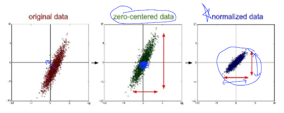

```python
bpc.Figure(bpc.ML07_IMG_06)
```

### Linear regression with min, max

```python
a = np.arange(4).reshape((2,2))
a
```

```
array([[0, 1],
       [2, 3]])
```

```python
np.min(a)
```

```
0
```

```python
np.min(a, axis=0)
```

```
array([0, 1])
```

```python
np.min(a, axis=1)
```

```
array([0, 2])
```

```python
import tensorflow as tf
import numpy as np

tf.set_random_seed(777)  # for reproducibility

def MinMaxScaler(data):
    numerator = data - np.min(data, 0)
    denominator = np.max(data, 0) - np.min(data, 0)
    print(" max.data :\n {max}, \n\n min.data :\n {min}, \n\n numerator :\n {numerator}, \n\n denominator :\n {denominator} \n".format(
            max = np.max(data, 0),
            min = np.min(data, 0),
            numerator = numerator,
            denominator = denominator
        ))

    # noise term prevents the zero division
    return numerator / (denominator + 1e-5)


xy = np.array([[828.659973, 833.450012, 908100,  828.349976, 831.659973],
               [823.02002,  828.070007, 1828100, 821.655029, 828.070007],
               [819.929993, 824.400024, 1438100, 818.97998,  824.159973],
               [816,        820.958984, 1008100, 815.48999,  819.23999 ],
               [819.359985, 823,        1188100, 818.469971, 818.97998 ],
               [819,        823,        1198100, 816,        820.450012],
               [811.700012, 815.25,     1098100, 809.780029, 813.669983],
               [809.51001,  816.659973, 1398100, 804.539978, 809.559998]])

# print("np.max(xy, 0) :", np.max(xy, 0))
# print("np.min(xy, 0) :", np.min(xy, 0))

# very important. It does not work without it.
xy = MinMaxScaler(xy)
print(" xy : MinMaxScaler(xy) = numerator / (denominator + 1e-7) \n", xy)

x_data = xy[:, 0:-1]
y_data = xy[:, [-1]]
print("\n x_data : \n{}  \n\n y_data : \n{}".format(x_data, y_data))

# placeholders for a tensor that will be always fed.
X = tf.placeholder(tf.float32, shape=[None, 4])
Y = tf.placeholder(tf.float32, shape=[None, 1])

W = tf.Variable(tf.random_normal([4, 1]), name='weight')
b = tf.Variable(tf.random_normal([1]), name='bias')

# Hypothesis
hypothesis = tf.matmul(X, W) + b

# Simplified cost/loss function
cost = tf.reduce_mean(tf.square(hypothesis - Y))

# Minimize
optimizer = tf.train.GradientDescentOptimizer(learning_rate=1e-5)
train = optimizer.minimize(cost)
```

```
 max.data :
 [8.28659973e+02 8.33450012e+02 1.82810000e+06 8.28349976e+02
 8.31659973e+02],

 min.data :
 [8.09510010e+02 8.15250000e+02 9.08100000e+05 8.04539978e+02
 8.09559998e+02],

 numerator :
 [[1.9149963e+01 1.8200012e+01 0.0000000e+00 2.3809998e+01 2.2099975e+01]
 [1.3510010e+01 1.2820007e+01 9.2000000e+05 1.7115051e+01 1.8510009e+01]
 [1.0419983e+01 9.1500240e+00 5.3000000e+05 1.4440002e+01 1.4599975e+01]
 [6.4899900e+00 5.7089840e+00 1.0000000e+05 1.0950012e+01 9.6799920e+00]
 [9.8499750e+00 7.7500000e+00 2.8000000e+05 1.3929993e+01 9.4199820e+00]
 [9.4899900e+00 7.7500000e+00 2.9000000e+05 1.1460022e+01 1.0890014e+01]
 [2.1900020e+00 0.0000000e+00 1.9000000e+05 5.2400510e+00 4.1099850e+00]
 [0.0000000e+00 1.4099730e+00 4.9000000e+05 0.0000000e+00 0.0000000e+00]],

 denominator :
 [1.9149963e+01 1.8200012e+01 9.2000000e+05 2.3809998e+01 2.2099975e+01]

 xy : MinMaxScaler(xy) = numerator / (denominator + 1e-7)
 [[0.99999948 0.99999945 0.         0.99999958 0.99999955]
 [0.70548455 0.70439514 1.         0.71881752 0.83755754]
 [0.54412521 0.50274796 0.57608696 0.60646775 0.6606328 ]
 [0.33890335 0.31368006 0.10869565 0.45989115 0.43800899]
 [0.51435973 0.42582366 0.30434783 0.58504781 0.42624382]
 [0.49556153 0.42582366 0.31521739 0.48131114 0.49276115]
 [0.11436058 0.         0.20652174 0.22007767 0.1859723 ]
 [0.         0.07747095 0.5326087  0.         0.        ]]

 x_data :
[[0.99999948 0.99999945 0.         0.99999958]
 [0.70548455 0.70439514 1.         0.71881752]
 [0.54412521 0.50274796 0.57608696 0.60646775]
 [0.33890335 0.31368006 0.10869565 0.45989115]
 [0.51435973 0.42582366 0.30434783 0.58504781]
 [0.49556153 0.42582366 0.31521739 0.48131114]
 [0.11436058 0.         0.20652174 0.22007767]
 [0.         0.07747095 0.5326087  0.        ]]

 y_data :
[[0.99999955]
 [0.83755754]
 [0.6606328 ]
 [0.43800899]
 [0.42624382]
 [0.49276115]
 [0.1859723 ]
 [0.        ]]
```

```python
# Launch the graph in a session.
sess = tf.Session()
# Initializes global variables in the graph.
sess.run(tf.global_variables_initializer())

prev_cost = 1
for step in tqdm_notebook(range(1001)):
    cost_val, hy_val, _ = sess.run(
        [cost, hypothesis, train], feed_dict={X: x_data, Y: y_data})

    if step%10 == 0:
        # print("\nStep", step, "\nCost:", cost_val, "\nPrediction:\n", hy_val)
        # print("Step : {}, \t Cost : {}".format(step, cost_val))
        improvement =  prev_cost - cost_val
        prev_cost = cost_val
        print("Step : {}, \t Cost : {}, \t Improvement : {}".format(step, cost_val,  improvement))
```

```
Step : 0, 	 Cost : 0.1672840714454651, 	 Improvement : 0.8327159285545349
Step : 10, 	 Cost : 0.1672743409872055, 	 Improvement : 9.73045825958252e-06
Step : 20, 	 Cost : 0.1672646403312683, 	 Improvement : 9.700655937194824e-06
Step : 30, 	 Cost : 0.1672549545764923, 	 Improvement : 9.685754776000977e-06
Step : 40, 	 Cost : 0.1672452688217163, 	 Improvement : 9.685754776000977e-06
Step : 50, 	 Cost : 0.16723555326461792, 	 Improvement : 9.715557098388672e-06
Step : 60, 	 Cost : 0.16722583770751953, 	 Improvement : 9.715557098388672e-06
Step : 70, 	 Cost : 0.16721615195274353, 	 Improvement : 9.685754776000977e-06
Step : 80, 	 Cost : 0.16720646619796753, 	 Improvement : 9.685754776000977e-06
Step : 90, 	 Cost : 0.16719679534435272, 	 Improvement : 9.670853614807129e-06
Step : 100, 	 Cost : 0.16718710958957672, 	 Improvement : 9.685754776000977e-06
Step : 110, 	 Cost : 0.16717743873596191, 	 Improvement : 9.670853614807129e-06
Step : 120, 	 Cost : 0.1671677529811859, 	 Improvement : 9.685754776000977e-06
Step : 130, 	 Cost : 0.16715805232524872, 	 Improvement : 9.700655937194824e-06
Step : 140, 	 Cost : 0.16714835166931152, 	 Improvement : 9.700655937194824e-06
Step : 150, 	 Cost : 0.1671386957168579, 	 Improvement : 9.655952453613281e-06
Step : 160, 	 Cost : 0.1671290099620819, 	 Improvement : 9.685754776000977e-06
Step : 170, 	 Cost : 0.1671193242073059, 	 Improvement : 9.685754776000977e-06
Step : 180, 	 Cost : 0.1671096831560135, 	 Improvement : 9.641051292419434e-06
Step : 190, 	 Cost : 0.16710004210472107, 	 Improvement : 9.641051292419434e-06
Step : 200, 	 Cost : 0.16709035634994507, 	 Improvement : 9.685754776000977e-06
Step : 210, 	 Cost : 0.16708070039749146, 	 Improvement : 9.655952453613281e-06
Step : 220, 	 Cost : 0.16707102954387665, 	 Improvement : 9.670853614807129e-06
Step : 230, 	 Cost : 0.16706135869026184, 	 Improvement : 9.670853614807129e-06
Step : 240, 	 Cost : 0.16705170273780823, 	 Improvement : 9.655952453613281e-06
Step : 250, 	 Cost : 0.16704204678535461, 	 Improvement : 9.655952453613281e-06
Step : 260, 	 Cost : 0.1670324057340622, 	 Improvement : 9.641051292419434e-06
Step : 270, 	 Cost : 0.1670227348804474, 	 Improvement : 9.670853614807129e-06
Step : 280, 	 Cost : 0.16701310873031616, 	 Improvement : 9.626150131225586e-06
Step : 290, 	 Cost : 0.16700346767902374, 	 Improvement : 9.641051292419434e-06
Step : 300, 	 Cost : 0.16699381172657013, 	 Improvement : 9.655952453613281e-06
Step : 310, 	 Cost : 0.1669841706752777, 	 Improvement : 9.641051292419434e-06
Step : 320, 	 Cost : 0.1669745147228241, 	 Improvement : 9.655952453613281e-06
Step : 330, 	 Cost : 0.16696488857269287, 	 Improvement : 9.626150131225586e-06
Step : 340, 	 Cost : 0.16695526242256165, 	 Improvement : 9.626150131225586e-06
Step : 350, 	 Cost : 0.16694563627243042, 	 Improvement : 9.626150131225586e-06
Step : 360, 	 Cost : 0.1669359654188156, 	 Improvement : 9.670853614807129e-06
Step : 370, 	 Cost : 0.16692635416984558, 	 Improvement : 9.611248970031738e-06
Step : 380, 	 Cost : 0.16691671311855316, 	 Improvement : 9.641051292419434e-06
Step : 390, 	 Cost : 0.16690710186958313, 	 Improvement : 9.611248970031738e-06
```

[output cut: 46 more lines]

```
Step : 860, 	 Cost : 0.16645926237106323, 	 Improvement : 9.506940841674805e-06
Step : 870, 	 Cost : 0.16644978523254395, 	 Improvement : 9.47713851928711e-06
Step : 880, 	 Cost : 0.16644029319286346, 	 Improvement : 9.492039680480957e-06
Step : 890, 	 Cost : 0.16643080115318298, 	 Improvement : 9.492039680480957e-06
Step : 900, 	 Cost : 0.1664213091135025, 	 Improvement : 9.492039680480957e-06
Step : 910, 	 Cost : 0.16641183197498322, 	 Improvement : 9.47713851928711e-06
Step : 920, 	 Cost : 0.16640238463878632, 	 Improvement : 9.447336196899414e-06
Step : 930, 	 Cost : 0.16639290750026703, 	 Improvement : 9.47713851928711e-06
Step : 940, 	 Cost : 0.16638344526290894, 	 Improvement : 9.462237358093262e-06
Step : 950, 	 Cost : 0.16637399792671204, 	 Improvement : 9.447336196899414e-06
Step : 960, 	 Cost : 0.16636450588703156, 	 Improvement : 9.492039680480957e-06
Step : 970, 	 Cost : 0.16635505855083466, 	 Improvement : 9.447336196899414e-06
Step : 980, 	 Cost : 0.16634559631347656, 	 Improvement : 9.462237358093262e-06
Step : 990, 	 Cost : 0.16633613407611847, 	 Improvement : 9.462237358093262e-06
Step : 1000, 	 Cost : 0.16632667183876038, 	 Improvement : 9.462237358093262e-06
```

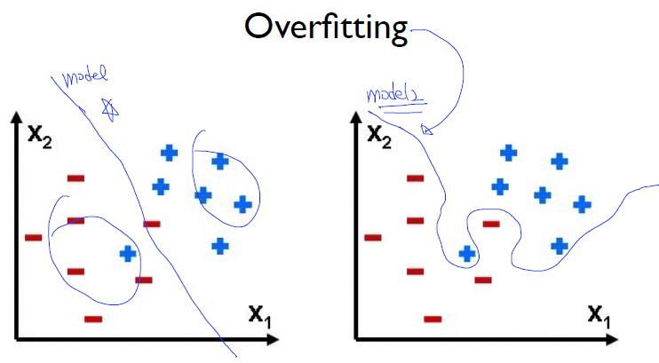

```python
bpc.Figure(bpc.ML07_IMG_07, 600)
```

# Solution for Overfitting

> - More training Data !
> - Reduce the number of features
> - Regularization

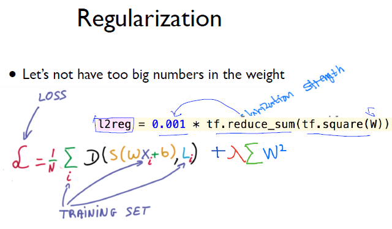

```python
bpc.Figure(bpc.ML07_IMG_08)
```

### MNIST

> MNIST (Modified National Institute of Standards and Technology)
> - MNIST is the de facto “hello world” dataset of computer vision. Since its release in 1999, this classic dataset of handwritten images has served as the basis for benchmarking classification algorithms.
> - As new machine learning techniques emerge, MNIST remains a reliable resource for researchers and learners alike.

### 손글씨 숫자데이터

> 미국 우편국에서 우편번호를 분리하기 위해 손글씨 데이터를 머신러닝에 적용

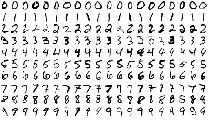

```python
bpc.Figure(bpc.ML07_IMG_09)
```

### training & test set

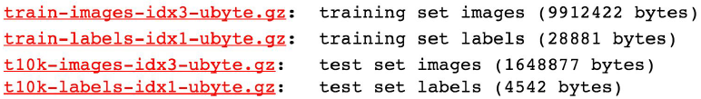

```python
bpc.Figure(bpc.ML07_IMG_10)

# from tensorflow.examples.tutorials.mnist import input_data
# mnist = input_data.read_data_sets("data/MNIST_data/", one_hot=True)
```

### In the Neural Network terminology

> - one epoch = one forward pass and one backward pass of all the training examples
> - batch size = the number of training examples in one forward/backward pass. The higher the batch size, the more memory space you'll need.
> - number of iterations = number of passes, each pass using [batch size] number of examples. To be clear, one pass = one forward pass + one backward pass (we do not count the forward pass and backward pass as two different passes).  
>   Example: if you have 1000 training examples, and your batch size is 500, then it will take 2 iterations to complete 1 epoch.
> - In digital circuits, one-hot refers to a group of bits among which the legal combinations of values are only those with a single high (1) bit and all the others low (0).

```python
# Learning rate and Evaluation
import tensorflow as tf
import random
import matplotlib.pyplot as plt

tf.set_random_seed(777)  # for reproducibility

from tensorflow.examples.tutorials.mnist import input_data
# Check out https://www.tensorflow.org/get_started/mnist/beginners for
# more information about the mnist dataset
# 맨처음 최초한번만 mnist 다운로딩 이후는 로컬데이터 사용
mnist = input_data.read_data_sets("data/MNIST_data/", one_hot=True)

nb_classes = 10

# MNIST data image of shape 28 * 28 = 784L
X = tf.placeholder(tf.float32, [None, 784])

# 0 - 9 digits recognition = 10 classes
Y = tf.placeholder(tf.float32, [None, nb_classes])

W = tf.Variable(tf.random_normal([784, nb_classes]))
b = tf.Variable(tf.random_normal([nb_classes]))

# Hypothesis (using softmax)
hypothesis = tf.nn.softmax(tf.matmul(X, W) + b)

cost = tf.reduce_mean(-tf.reduce_sum(Y * tf.log(hypothesis), axis=1))
optimizer = tf.train.GradientDescentOptimizer(learning_rate=0.1).minimize(cost)

# Test model
is_correct = tf.equal(tf.arg_max(hypothesis, 1), tf.arg_max(Y, 1))

# Calculate accuracy
accuracy = tf.reduce_mean(tf.cast(is_correct, tf.float32))
```

[output not shown]

### Training epoch / batch

> - epoch : one forward pass and one backward pass of all the training examples
> - batch : the number of training examples in one forward/backward pass
> - iterations : number of passes, each pass using [batch size] number of examples  
>   Ex.  
>   if you have 1000 training examples, and your batch size is 500,  
>   then it will take 2 iterations to complete 1 epoch.

```python
mnist.train.num_examples
```

```
55000
```

```
Epoch: 0001	Cost = 2.814546387
Epoch: 0002	Cost = 1.138760638
Epoch: 0003	Cost = 0.906234492
Epoch: 0004	Cost = 0.790985894
Epoch: 0005	Cost = 0.718591672
Epoch: 0006	Cost = 0.667473709
Epoch: 0007	Cost = 0.628179321
Epoch: 0008	Cost = 0.597087100
Epoch: 0009	Cost = 0.571154184
Epoch: 0010	Cost = 0.549675502
Epoch: 0011	Cost = 0.531540276
Epoch: 0012	Cost = 0.514862219
Epoch: 0013	Cost = 0.500897732
Epoch: 0014	Cost = 0.488344262
Epoch: 0015	Cost = 0.476432258

Learning finished
----------------------------------------------------------------
Accuracy:  0.8892
Label:  [4]
Prediction:  [4]
```

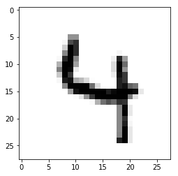

```python
# parameters
training_epochs = 15
batch_size = 100

with tf.Session() as sess:
    # Initialize TensorFlow variables
    sess.run(tf.global_variables_initializer())

    # Training cycle
    for epoch in tqdm_notebook(range(training_epochs)):
        avg_cost = 0
        total_batch = int(mnist.train.num_examples / batch_size)

        for i in range(total_batch):
            batch_xs, batch_ys = mnist.train.next_batch(batch_size)
            c, _ = sess.run([cost, optimizer], feed_dict={
                            X: batch_xs, Y: batch_ys})
            avg_cost += c / total_batch

        # print('Epoch:', '%04d' % (epoch + 1),
        #       '\t cost =', '{:.9f}'.format(avg_cost))
        print('Epoch:', '%04d' % (epoch + 1), end='\t')
        print('Cost =', '{:.9f}'.format(avg_cost))


    print("Learning finished")
    print("-"*2**6)

    # Test the model using test sets
    print("Accuracy: ", accuracy.eval(session=sess, feed_dict={
          X: mnist.test.images, Y: mnist.test.labels}))

    # Get one and predict
    r = random.randint(0, mnist.test.num_examples - 1)
    print("Label: ", sess.run(tf.argmax(mnist.test.labels[r:r + 1], 1)))
    print("Prediction: ", sess.run(
        tf.argmax(hypothesis, 1), feed_dict={X: mnist.test.images[r:r + 1]}))

    plt.imshow(mnist.test.images[r:r + 1].reshape(28,28), cmap='Greys', interpolation='nearest')
    plt.show()
```

[output not shown]

```python
# parameters
training_epochs = 15
batch_size = 100

sess = tf.Session()
# Initialize TensorFlow variables
sess.run(tf.global_variables_initializer())
# Training cycle
for epoch in range(training_epochs):
    avg_cost = 0
    total_batch = int(mnist.train.num_examples / batch_size)

    for i in range(total_batch):
        batch_xs, batch_ys = mnist.train.next_batch(batch_size)
        c, _ = sess.run([cost, optimizer], feed_dict={
                        X: batch_xs, Y: batch_ys})
        avg_cost += c / total_batch

        if i % (total_batch/100) == 0:
            print('▒', end='')

    print(' 100% ')
    print('Epoch:', '%04d' % (epoch + 1), end='\t')
    print('Cost =', '{:.9f}'.format(avg_cost))

print()
print("Learning finished")

# Test the model using test sets
# print("Accuracy: ", accuracy.eval(session=sess, feed_dict={
#       X: mnist.test.images, Y: mnist.test.labels}))
```

```
▒▒▒▒▒▒▒▒▒▒▒▒▒▒▒▒▒▒▒▒▒▒▒▒▒▒▒▒▒▒▒▒▒▒▒▒▒▒▒▒▒▒▒▒▒▒▒▒▒▒ 100%
Epoch: 0001	Cost = 2.825194640
▒▒▒▒▒▒▒▒▒▒▒▒▒▒▒▒▒▒▒▒▒▒▒▒▒▒▒▒▒▒▒▒▒▒▒▒▒▒▒▒▒▒▒▒▒▒▒▒▒▒ 100%
Epoch: 0002	Cost = 1.139397094
▒▒▒▒▒▒▒▒▒▒▒▒▒▒▒▒▒▒▒▒▒▒▒▒▒▒▒▒▒▒▒▒▒▒▒▒▒▒▒▒▒▒▒▒▒▒▒▒▒▒ 100%
Epoch: 0003	Cost = 0.905856994
▒▒▒▒▒▒▒▒▒▒▒▒▒▒▒▒▒▒▒▒▒▒▒▒▒▒▒▒▒▒▒▒▒▒▒▒▒▒▒▒▒▒▒▒▒▒▒▒▒▒ 100%
Epoch: 0004	Cost = 0.791128663
▒▒▒▒▒▒▒▒▒▒▒▒▒▒▒▒▒▒▒▒▒▒▒▒▒▒▒▒▒▒▒▒▒▒▒▒▒▒▒▒▒▒▒▒▒▒▒▒▒▒ 100%
Epoch: 0005	Cost = 0.718489880
▒▒▒▒▒▒▒▒▒▒▒▒▒▒▒▒▒▒▒▒▒▒▒▒▒▒▒▒▒▒▒▒▒▒▒▒▒▒▒▒▒▒▒▒▒▒▒▒▒▒ 100%
Epoch: 0006	Cost = 0.666858064
▒▒▒▒▒▒▒▒▒▒▒▒▒▒▒▒▒▒▒▒▒▒▒▒▒▒▒▒▒▒▒▒▒▒▒▒▒▒▒▒▒▒▒▒▒▒▒▒▒▒ 100%
Epoch: 0007	Cost = 0.627803853
▒▒▒▒▒▒▒▒▒▒▒▒▒▒▒▒▒▒▒▒▒▒▒▒▒▒▒▒▒▒▒▒▒▒▒▒▒▒▒▒▒▒▒▒▒▒▒▒▒▒ 100%
Epoch: 0008	Cost = 0.596639068
▒▒▒▒▒▒▒▒▒▒▒▒▒▒▒▒▒▒▒▒▒▒▒▒▒▒▒▒▒▒▒▒▒▒▒▒▒▒▒▒▒▒▒▒▒▒▒▒▒▒ 100%
Epoch: 0009	Cost = 0.570643420
▒▒▒▒▒▒▒▒▒▒▒▒▒▒▒▒▒▒▒▒▒▒▒▒▒▒▒▒▒▒▒▒▒▒▒▒▒▒▒▒▒▒▒▒▒▒▒▒▒▒ 100%
Epoch: 0010	Cost = 0.549209553
▒▒▒▒▒▒▒▒▒▒▒▒▒▒▒▒▒▒▒▒▒▒▒▒▒▒▒▒▒▒▒▒▒▒▒▒▒▒▒▒▒▒▒▒▒▒▒▒▒▒ 100%
Epoch: 0011	Cost = 0.531092984
▒▒▒▒▒▒▒▒▒▒▒▒▒▒▒▒▒▒▒▒▒▒▒▒▒▒▒▒▒▒▒▒▒▒▒▒▒▒▒▒▒▒▒▒▒▒▒▒▒▒ 100%
Epoch: 0012	Cost = 0.514850765
▒▒▒▒▒▒▒▒▒▒▒▒▒▒▒▒▒▒▒▒▒▒▒▒▒▒▒▒▒▒▒▒▒▒▒▒▒▒▒▒▒▒▒▒▒▒▒▒▒▒ 100%
Epoch: 0013	Cost = 0.500835596
▒▒▒▒▒▒▒▒▒▒▒▒▒▒▒▒▒▒▒▒▒▒▒▒▒▒▒▒▒▒▒▒▒▒▒▒▒▒▒▒▒▒▒▒▒▒▒▒▒▒ 100%
Epoch: 0014	Cost = 0.487953309
▒▒▒▒▒▒▒▒▒▒▒▒▒▒▒▒▒▒▒▒▒▒▒▒▒▒▒▒▒▒▒▒▒▒▒▒▒▒▒▒▒▒▒▒▒▒▒▒▒▒ 100%
Epoch: 0015	Cost = 0.476886634

Learning finished
```

### Report result on test dataset

```python
# Test the model using test sets
print("Accuracy: ", accuracy.eval(session=sess, feed_dict={
      X: mnist.test.images, Y: mnist.test.labels}))
```

```
Accuracy:  0.8892
```

### Sample image show and prediction

> - 랜덤하게 읽어온 이미지를 예측하여 실제 맞는지를 확인한다.

```
Label:  [0]
Prediction:  [0]
```

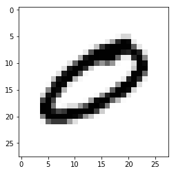

```python
# Get one and predict
r = random.randint(0, mnist.test.num_examples - 1)
print("Label: ", sess.run(tf.argmax(mnist.test.labels[r:r + 1], 1)))
print("Prediction: ", sess.run(
    tf.argmax(hypothesis, 1), feed_dict={X: mnist.test.images[r:r + 1]}))

plt.imshow(mnist.test.images[r:r + 1].reshape(28,28), cmap='Greys', interpolation='nearest')
plt.show()
```

```python
type(mnist.test.num_examples)
```

```
int
```

```python
mnist.test.num_examples
```

```
10000
```

```
r: 6050
Label:  [7]
Prediction:  [7]
```

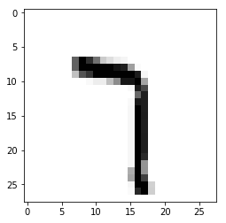

```python
# Get one and predict
r = random.randint(0, mnist.test.num_examples - 1)
print("r:", r)
print("Label: ", sess.run(tf.argmax(mnist.test.labels[r:r + 1], 1)))
print("Prediction: ", sess.run(
    tf.argmax(hypothesis, 1), feed_dict={X: mnist.test.images[r:r + 1]}))

plt.imshow(mnist.test.images[r:r + 1].reshape(28,28), cmap='Greys', interpolation='nearest')
plt.show()
```

```
r: 2395
Label:  [8]
Prediction:  [5]
```

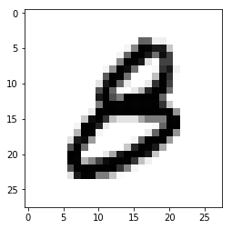

```
r: 3712
Label:  [6]
Prediction:  [6]
```

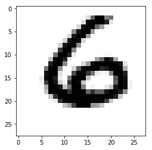

```
r: 2803
Label:  [1]
Prediction:  [1]
```

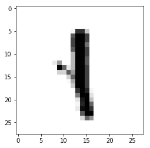

```
r: 6536
Label:  [4]
Prediction:  [4]
```

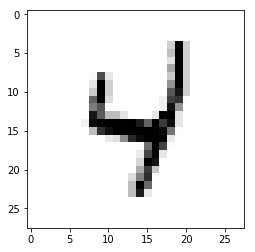

```
r: 4857
Label:  [0]
Prediction:  [0]
```

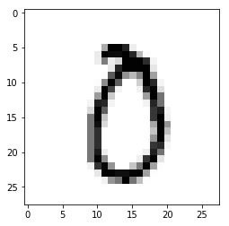

```
r: 1937
Label:  [6]
Prediction:  [6]
```

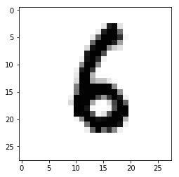

```
r: 5694
Label:  [6]
Prediction:  [6]
```

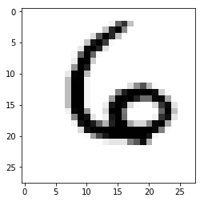

```
r: 7216
Label:  [0]
Prediction:  [4]
```

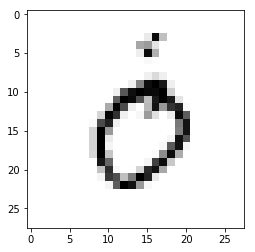

```
r: 7882
Label:  [0]
Prediction:  [0]
```

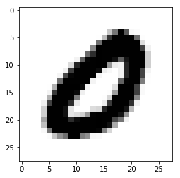

```
r: 8206
Label:  [3]
Prediction:  [3]
```

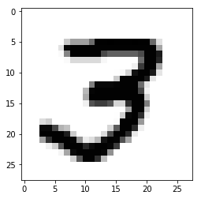

```python
for i in range(10):
    # Get one and predict
    r = random.randint(0, mnist.test.num_examples - 1)
    print("r:", r)
    print("Label: ", sess.run(tf.argmax(mnist.test.labels[r:r + 1], 1)))
    print("Prediction: ", sess.run(
        tf.argmax(hypothesis, 1), feed_dict={X: mnist.test.images[r:r + 1]}))

    plt.imshow(mnist.test.images[r:r + 1].reshape(28,28), cmap='Greys', interpolation='nearest')
    plt.show()
```

The BigpyCraft find the information to design valuable society with Technology & Craft.

< The End >